# Capítulo: Análisis para la Agregación Espaciotemporal

De eventos de falla individuales a panel cuadrante × semana

Cindy Lugo

2026-06-08

```r
# ── Manipulación de datos ──────────────────────────────────────────────
library(tidyverse)
library(lubridate)
library(readxl)

# ── Análisis espacial ──────────────────────────────────────────────────
library(sf)            # objetos espaciales
library(spdep)         # autocorrelación espacial (Moran, vecindades)
library(spatstat)      # patrones puntuales (K de Ripley, densidad)
library(gstat)         # semivariogramas
library(sp)            # clases sp (requerido por gstat)

# ── Visualización ──────────────────────────────────────────────────────
library(ggplot2)
library(patchwork)
library(viridis)
library(knitr)
library(kableExtra)
```

```r
# ── Rutas ──────────────────────────────────────────────────────────────
env_path <- file.path("..", "..", ".env")
if (file.exists(".env")) {
  readRenviron(".env")
} else if (file.exists(env_path)) {
  readRenviron(env_path)
}

UBICACION_DATA <- Sys.getenv("UBICACION_DATA")
if (UBICACION_DATA == "") stop("UBICACION_DATA no está definida. Verifica el archivo .env.")

path_consolidada  <- file.path(UBICACION_DATA, "data_consolidada.csv")
path_cuadrantes   <- file.path(UBICACION_DATA, "Distribución de Cuadrantes", "CUADRANTE_CORD_800.xls")
path_elem_cuad    <- file.path(UBICACION_DATA, "Distribución de Cuadrantes", "ELEMENTO_FALLA_CUADRANTE_800.xls")

for (p in c(path_consolidada, path_cuadrantes, path_elem_cuad)) {
  if (!file.exists(p)) stop("No se encontró: ", p)
}
```

# 1 Introducción y motivación metodológica

El análisis de la confiabilidad de redes de distribución eléctrica requiere decisiones metodológicas explícitas sobre la **escala espacial y temporal** de observación. La base de datos original registra eventos de falla al nivel del **activo individual × día**, lo que genera un panel de dimensiones considerables ($N = A \times T$, con $A \approx 47{,}649$ activos y $T = 1{,}826$ días). Operar directamente con este panel presenta dos desafíos:

1. **Complejidad computacional:** el volumen dificulta la estimación de modelos espaciales con matrices de vecindad densas.
2. **Esparcidad de eventos:** la mayoría de activos registran cero fallas en cualquier día dado, lo que genera problemas de inflación de ceros en los modelos de conteo o duración.

El análisis utiliza los datos del **último trimestre de 2025** (octubre–diciembre), período suficientemente reciente y con registros completos de variables climáticas.

# 2 Carga y preparación de datos

```r
message("Leyendo panel consolidado...")
tabla_base <- read_csv(path_consolidada, show_col_types = FALSE)

# Tabla de asignación elemento → cuadrante
elemento_cuadrante <- read_excel(path_elem_cuad) %>%
  select(ELEMENTO, CUADRANTE_1) %>%
  distinct() %>%
  rename(id_cuadrante = CUADRANTE_1)

# Coordenadas de cuadrantes
cuadrante_coord <- read_excel(path_cuadrantes)

# Unir cuadrante al panel principal
tabla_base <- tabla_base %>%
  left_join(elemento_cuadrante, by = "ELEMENTO")

message("Dimensiones del panel completo: ", paste(dim(tabla_base), collapse = " × "))
```

```r
# ── Filtrar: octubre – diciembre 2025 ─────────────────────────────────
datos_q4 <- tabla_base %>%
  filter(
    FECHA_DIA >= as.Date("2025-10-01"),
    FECHA_DIA <= as.Date("2025-12-31")
  )

message("Filas en Q4-2025: ", nrow(datos_q4))
message("Cuadrantes con datos: ", n_distinct(datos_q4$id_cuadrante))
message("Activos con datos: ",    n_distinct(datos_q4$ELEMENTO))
```

```r
# Resumen de cobertura temporal
cobertura <- datos_q4 %>%
  summarise(
    fecha_inicio   = min(FECHA_DIA),
    fecha_fin      = max(FECHA_DIA),
    n_dias         = n_distinct(FECHA_DIA),
    n_activos      = n_distinct(ELEMENTO),
    n_cuadrantes   = n_distinct(id_cuadrante),
    total_eventos  = sum(FRECUENCIA, na.rm = TRUE),
    activos_con_falla = sum(FRECUENCIA > 0, na.rm = TRUE)
  )

kable(cobertura, caption = "Cobertura de los datos Q4-2025",
      format.args = list(big.mark = ",")) %>%
  kable_styling(bootstrap_options = c("striped", "hover"), full_width = FALSE)
```

Cobertura de los datos Q4-2025

| fecha_inicio | fecha_fin | n_dias | n_activos | n_cuadrantes | total_eventos | activos_con_falla |
| --- | --- | --- | --- | --- | --- | --- |
| 2025-10-01 | 2025-12-31 | 92 | 47,649 | 344 | 4,464 | 4,433 |

```r
# Extraer sólo registros con al menos una falla (eventos reales)
eventos_falla <- datos_q4 %>%
  filter(FRECUENCIA > 0) %>%
  select(ELEMENTO, TIPO, LATITUD, LONGITUD, ALTITUD,
         FECHA_DIA, FRECUENCIA, DURACION_min, id_cuadrante,
         temperatura_media_c, precipitacion_total_mm,
         humedad_relativa_pct, velocidad_viento_ms)

message("Eventos de falla en Q4-2025: ", nrow(eventos_falla))
```

# 3 Análisis descriptivo de los eventos

## 3.1 Distribución temporal de fallas

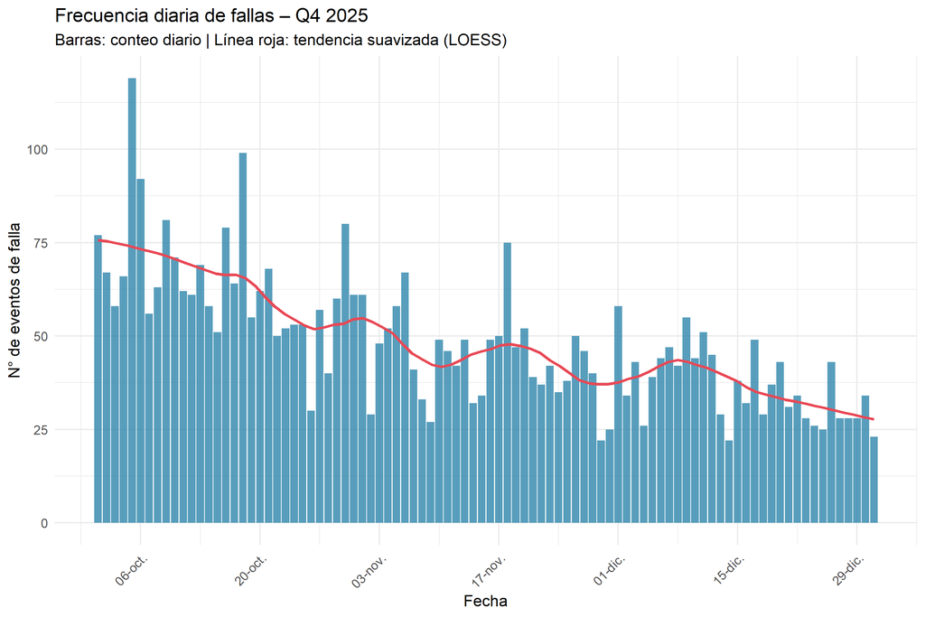

Figura 1. Frecuencia diaria de eventos de falla, Q4-2025.

```r
fallas_diarias <- eventos_falla %>%
  group_by(FECHA_DIA) %>%
  summarise(n_fallas = sum(FRECUENCIA), .groups = "drop")

p1 <- ggplot(fallas_diarias, aes(x = FECHA_DIA, y = n_fallas)) +
  geom_col(fill = "#2E86AB", alpha = 0.8) +
  geom_smooth(se = FALSE, color = "#E84855", linewidth = 1, method = "loess", span = 0.3) +
  scale_x_date(date_breaks = "2 weeks", date_labels = "%d-%b") +
  labs(
    title    = "Frecuencia diaria de fallas – Q4 2025",
    subtitle = "Barras: conteo diario | Línea roja: tendencia suavizada (LOESS)",
    x = "Fecha", y = "N° de eventos de falla"
  ) +
  theme_minimal(base_size = 11) +
  theme(axis.text.x = element_text(angle = 45, hjust = 1))

p1
```

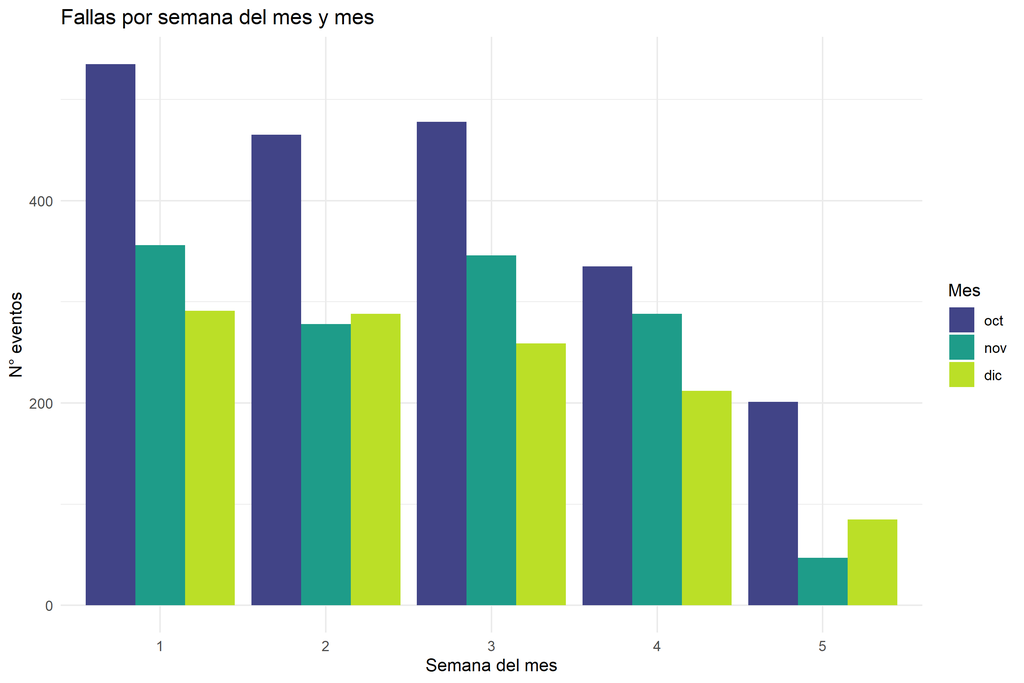

Figura 2. Distribución de fallas por semana del mes y mes.

```r
fallas_sem <- eventos_falla %>%
  mutate(
    mes     = month(FECHA_DIA, label = TRUE, locale = "es"),
    sem_mes = ceiling(day(FECHA_DIA) / 7)
  ) %>%
  group_by(mes, sem_mes) %>%
  summarise(n = sum(FRECUENCIA), .groups = "drop")

p2 <- ggplot(fallas_sem, aes(x = factor(sem_mes), y = n, fill = mes)) +
  geom_col(position = "dodge") +
  scale_fill_viridis_d(option = "D", begin = 0.2, end = 0.9) +
  labs(title = "Fallas por semana del mes y mes", x = "Semana del mes", y = "N° eventos",
       fill = "Mes") +
  theme_minimal(base_size = 11)

p2
```

**Interpretación:** Se observa variabilidad temporal clara entre semanas y meses, lo que sugiere la existencia de patrones temporales no estacionarios. La agregación semanal permite capturar ciclos recurrentes sin la alta volatilidad diaria.

## 3.2 Distribución espacial de fallas por cuadrante

```r
fallas_cuad <- eventos_falla %>%
  group_by(id_cuadrante) %>%
  summarise(
    n_eventos      = sum(FRECUENCIA),
    duracion_total = sum(DURACION_min) / 60,
    n_activos      = n_distinct(ELEMENTO),
    lat            = mean(LATITUD),
    lon            = mean(LONGITUD),
    .groups = "drop"
  )

# Estadísticas descriptivas
desc_cuad <- fallas_cuad %>%
  summarise(
    n_cuadrantes         = n(),
    cuad_sin_falla       = sum(n_eventos == 0),
    cuad_con_falla       = sum(n_eventos > 0),
    pct_con_falla        = round(mean(n_eventos > 0) * 100, 1),
    media_eventos        = round(mean(n_eventos), 2),
    mediana_eventos      = median(n_eventos),
    p90_eventos          = quantile(n_eventos, 0.9),
    max_eventos          = max(n_eventos)
  )

kable(desc_cuad, caption = "Tabla 1. Distribución de fallas por cuadrante – Q4 2025",
      format.args = list(big.mark = ",")) %>%
  kable_styling(bootstrap_options = c("striped", "hover"), full_width = FALSE)
```

Tabla 1. Distribución de fallas por cuadrante – Q4 2025

| n_cuadrantes | cuad_sin_falla | cuad_con_falla | pct_con_falla | media_eventos | mediana_eventos | p90_eventos | max_eventos |
| --- | --- | --- | --- | --- | --- | --- | --- |
| 290 | 0 | 290 | 100 | 15.39 | 10 | 35 | 214 |

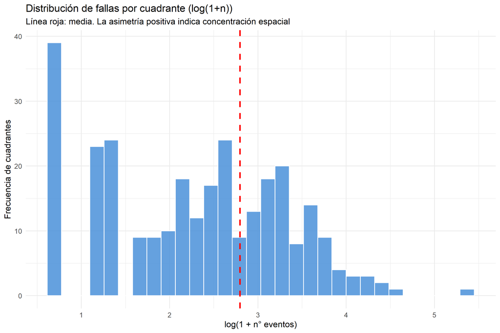

Figura 3. Histograma de eventos por cuadrante (escala log+1).

```r
ggplot(fallas_cuad, aes(x = log1p(n_eventos))) +
  geom_histogram(bins = 30, fill = "#4A90D9", color = "white", alpha = 0.85) +
  geom_vline(xintercept = log1p(mean(fallas_cuad$n_eventos)),
             color = "red", linetype = "dashed", linewidth = 1) +
  labs(
    title    = "Distribución de fallas por cuadrante (log(1+n))",
    subtitle = "Línea roja: media. La asimetría positiva indica concentración espacial",
    x        = "log(1 + n° eventos)",
    y        = "Frecuencia de cuadrantes"
  ) +
  theme_minimal(base_size = 11)
```

# 4 Análisis de patrones puntuales espaciales

Esta sección trata los eventos de falla como un **proceso puntual espacial** y evalúa si su distribución es aleatoria (Proceso de Poisson Homogéneo, CSR) o presenta agrupamiento.

## 4.1 Mapa de eventos y densidad Kernel

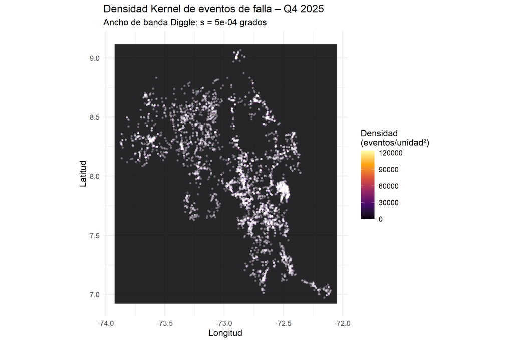

Figura 4. Localización de eventos de falla y densidad Kernel (KDE).

```r
# Convertir a objeto sf para mapeo
eventos_sf <- eventos_falla %>%
  filter(!is.na(LATITUD), !is.na(LONGITUD)) %>%
  st_as_sf(coords = c("LONGITUD", "LATITUD"), crs = 4326)

# Crear ventana espacial (bounding box + buffer)
bbox_eventos <- st_bbox(eventos_sf)
x_range <- c(bbox_eventos["xmin"] - 0.05, bbox_eventos["xmax"] + 0.05)
y_range <- c(bbox_eventos["ymin"] - 0.05, bbox_eventos["ymax"] + 0.05)

# ── KDE con spatstat ───────────────────────────────────────────────────
coords_mat <- st_coordinates(eventos_sf)
ppp_eventos <- ppp(
  x      = coords_mat[, 1],
  y      = coords_mat[, 2],
  window = owin(xrange = x_range, yrange = y_range)
)

# Ancho de banda de Silverman
bw_silverman <- bw.diggle(ppp_eventos)

kde_result <- density(ppp_eventos, sigma = bw_silverman)

# Convertir KDE a data frame para ggplot
kde_df <- as.data.frame(kde_result) %>%
  rename(lon = x, lat = y, intensidad = value)

# Datos de eventos para overlay
eventos_df <- as.data.frame(coords_mat) %>%
  rename(lon = X, lat = Y)

ggplot() +
  geom_raster(data = kde_df, aes(x = lon, y = lat, fill = intensidad), alpha = 0.85) +
  geom_point(data = eventos_df, aes(x = lon, y = lat),
             color = "white", alpha = 0.25, size = 0.8) +
  scale_fill_viridis_c(option = "inferno", name = "Densidad\n(eventos/unidad²)") +
  coord_equal() +
  labs(
    title    = "Densidad Kernel de eventos de falla – Q4 2025",
    subtitle = paste0("Ancho de banda Diggle: σ = ", round(bw_silverman, 4), " grados"),
    x = "Longitud", y = "Latitud"
  ) +
  theme_minimal(base_size = 11)
```

**Interpretación:** La densidad Kernel revela **zonas de concentración diferenciadas**, con núcleos de alta intensidad que contrastan con áreas de baja o nula actividad. Esto es una primera evidencia visual de que las fallas no se distribuyen de manera homogénea en el espacio.

## 4.2 Función K de Ripley: ¿agrupamiento o dispersión?

La función $K(r)$ mide la intensidad esperada de eventos dentro de un radio $r$ alrededor de un evento típico, corregida por la intensidad global $\lambda$:

$$\hat{K}(r) = \frac{1}{\hat{\lambda}^2
|A|} \sum_{i \neq j} \mathbf{1}(d_{ij} \leq r)$$

Si $\hat{K}(r) > \pi r^2$ (valor bajo CSR), existe **agrupamiento** a la escala $r$.

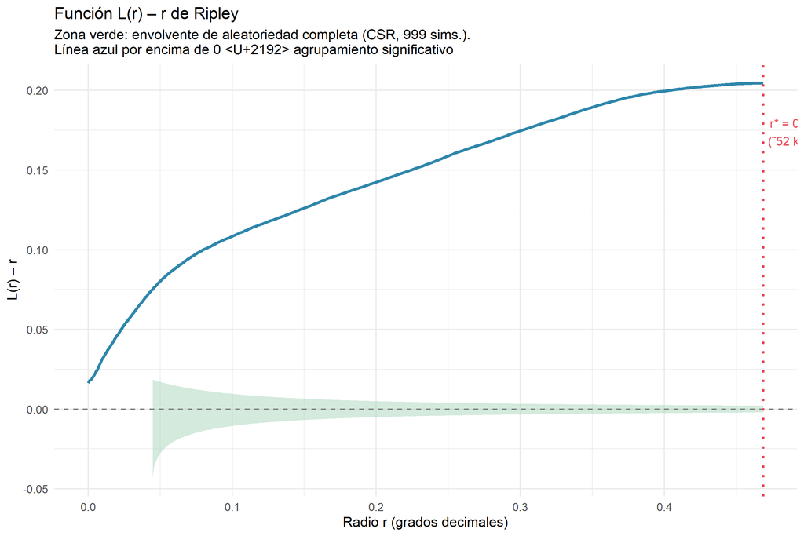

Figura 5. Función K de Ripley con envolvente de simulación Monte Carlo (999 simulaciones).

```r
set.seed(42)

# Calcular K observada y envolvente CSR (999 simulaciones)
k_obs <- Kest(ppp_eventos, correction = "Ripley")

k_env <- envelope(
  ppp_eventos,
  fun       = Kest,
  nsim      = 999,
  correction = "Ripley",
  verbose   = FALSE,
  global    = TRUE   # envolvente global (más estricta)
)

# Convertir a data frame
k_df <- as.data.frame(k_env)

# Gráfico L(r) - r (transformación estabilizadora de varianza)
k_df <- k_df %>%
  mutate(
    L_obs = sqrt(obs  / pi) - r,
    L_lo  = sqrt(lo   / pi) - r,
    L_hi  = sqrt(hi   / pi) - r,
    L_teo = 0   # bajo CSR, L(r)-r = 0
  )

# Identificar radio de máximo agrupamiento
r_max_cluster <- k_df$r[which.max(k_df$L_obs)]

ggplot(k_df, aes(x = r)) +
  geom_ribbon(aes(ymin = L_lo, ymax = L_hi), fill = "#A8D5BA", alpha = 0.5) +
  geom_hline(yintercept = 0, linetype = "dashed", color = "gray50") +
  geom_line(aes(y = L_obs), color = "#2E86AB", linewidth = 1.2) +
  geom_vline(xintercept = r_max_cluster, linetype = "dotted",
             color = "#E84855", linewidth = 1) +
  annotate("text", x = r_max_cluster, y = max(k_df$L_obs) * 0.85,
           label = paste0("r* = ", round(r_max_cluster, 4), "°\n(≈",
                          round(r_max_cluster * 111, 1), " km)"),
           color = "#E84855", hjust = -0.1, size = 3.5) +
  labs(
    title    = "Función L(r) – r de Ripley",
    subtitle = "Zona verde: envolvente de aleatoriedad completa (CSR, 999 sims.).\nLínea azul por encima de 0 → agrupamiento significativo",
    x        = "Radio r (grados decimales)",
    y        = "L(r) – r"
  ) +
  theme_minimal(base_size = 11)
```

```r
# Rango donde existe agrupamiento significativo
rango_cluster <- k_df %>%
  filter(L_obs > L_hi) %>%
  summarise(r_min = min(r), r_max = max(r))

cat("Agrupamiento significativo (L(r) > envolvente superior):\n")
```

```
## Agrupamiento significativo (L(r) > envolvente superior):
```

```r
cat("  Desde r =", round(rango_cluster$r_min, 4), "° (",
    round(rango_cluster$r_min * 111, 2), "km)\n")
```

```
##   Desde r = 0.0119 ° ( 1.32 km)
```

```r
cat("  Hasta  r =", round(rango_cluster$r_max, 4), "° (",
    round(rango_cluster$r_max * 111, 2), "km)\n")
```

```
##   Hasta  r = 0.4687 ° ( 52.02 km)
```

```r
cat("  Radio de máximo agrupamiento r* =", round(r_max_cluster, 4), "° (",
    round(r_max_cluster * 111, 2), "km)\n")
```

```
##   Radio de máximo agrupamiento r* = 0.4687 ° ( 52.02 km)
```

## 4.3 Prueba de aleatoriedad espacial completa (CSR)

```r
# Prueba basada en el estadístico de cuadrantes (quadrat count test)
qt <- quadrat.test(ppp_eventos, nx = 10, ny = 10, method = "Chisq")

cat("=== Prueba Chi-cuadrado de cuadrantes (CSR) ===\n")
```

```
## === Prueba Chi-cuadrado de cuadrantes (CSR) ===
```

```r
print(qt)
```

```
##
##  Chi-squared test of CSR using quadrat counts
##
## data:  ppp_eventos
## X2 = 13224, df = 99, p-value < 2.2e-16
## alternative hypothesis: two.sided
##
## Quadrats: 10 by 10 grid of tiles
```

```r
cat("\nInterpretación: p-valor =", round(qt$p.value, 6),
    ifelse(qt$p.value < 0.05,
           "→ Se rechaza CSR. Las fallas no son espacialmente aleatorias.",
           "→ No se rechaza CSR."))
```

```
##
## Interpretación: p-valor = 0 → Se rechaza CSR. Las fallas no son espacialmente aleatorias.
```

[figure not shown]

```r
plot(qt, main = "Prueba de cuadrantes (CSR)\nNúmero observado / esperado por celda")
```

# 5 Análisis de autocorrelación espacial

## 5.1 Preparación de la estructura de vecindad

```r
# Usar los cuadrantes con al menos un evento
cuad_con_datos <- fallas_cuad %>%
  filter(!is.na(lat), !is.na(lon))

# Convertir a sf
cuad_sf <- cuad_con_datos %>%
  st_as_sf(coords = c("lon", "lat"), crs = 4326)

# Construir matriz de vecinos (k = 5 vecinos más cercanos)
coords_cuad <- st_coordinates(cuad_sf)
knn5         <- knearneigh(coords_cuad, k = 5)
nb_knn5      <- knn2nb(knn5)
lw_knn5      <- nb2listw(nb_knn5, style = "W")

cat("Vecindad construida:", length(nb_knn5), "cuadrantes, k = 5 vecinos más cercanos\n")
```

```
## Vecindad construida: 290 cuadrantes, k = 5 vecinos más cercanos
```

## 5.2 Índice de Moran Global

El índice de Moran $I$ mide la autocorrelación espacial global:

$$I = \frac{n}{\sum_i \sum_j w_{ij}} \cdot
\frac{\sum_i \sum_j w_{ij}(x_i - \bar{x})(x_j - \bar{x})}{\sum_i (x_i -
\bar{x})^2}$$

Valores $I > E[I]$ indican agrupamiento; $I < E[I]$ dispersión.

```r
# Moran para n_eventos
moran_eventos <- moran.test(
  cuad_con_datos$n_eventos,
  listw = lw_knn5,
  alternative = "greater"
)

# Moran para duracion_total
moran_duracion <- moran.test(
  cuad_con_datos$duracion_total,
  listw = lw_knn5,
  alternative = "greater"
)

resultados_moran <- tibble(
  Variable   = c("N° eventos (SAIFI proxy)", "Duración total en horas (SAIDI proxy)"),
  `I de Moran` = c(round(moran_eventos$estimate["Moran I statistic"], 4),
                    round(moran_duracion$estimate["Moran I statistic"], 4)),
  `E[I]`      = c(round(moran_eventos$estimate["Expectation"], 6),
                   round(moran_duracion$estimate["Expectation"], 6)),
  `Z`         = c(round(moran_eventos$statistic, 3),
                   round(moran_duracion$statistic, 3)),
  `p-valor`   = c(format.pval(moran_eventos$p.value, digits = 4),
                   format.pval(moran_duracion$p.value, digits = 4)),
  `Conclusión` = c(
    ifelse(moran_eventos$p.value  < 0.05, "Agrupamiento significativo ✔", "Sin evidencia de agrupamiento"),
    ifelse(moran_duracion$p.value < 0.05, "Agrupamiento significativo ✔", "Sin evidencia de agrupamiento")
  )
)

kable(resultados_moran,
      caption = "Tabla 2. Índice de Moran Global – Q4 2025") %>%
  kable_styling(bootstrap_options = c("striped", "hover"), full_width = FALSE)
```

Tabla 2. Índice de Moran Global – Q4 2025

| Variable | I de Moran | E[I] | Z | p-valor | Conclusión |
| --- | --- | --- | --- | --- | --- |
| N° eventos (SAIFI proxy) | 0.2864 | -0.00346 | 8.760 | < 2.2e-16 | Agrupamiento significativo ✔ |
| Duración total en horas (SAIDI proxy) | 0.3611 | -0.00346 | 10.398 | < 2.2e-16 | Agrupamiento significativo ✔ |

## 5.3 Diagrama de dispersión de Moran

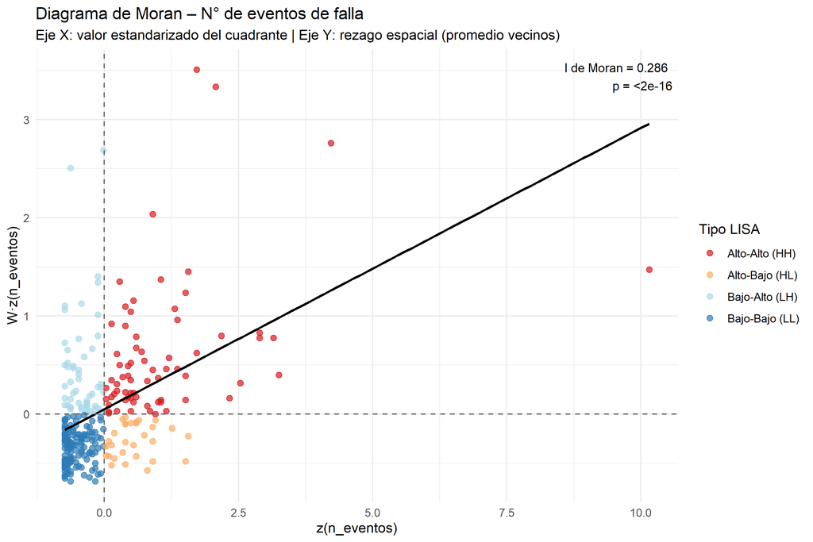

Figura 7. Diagrama de dispersión de Moran para el número de eventos de falla.

```r
# Calcular rezago espacial
cuad_con_datos <- cuad_con_datos %>%
  mutate(
    z_eventos  = scale(n_eventos)[,1],
    wz_eventos = lag.listw(lw_knn5, z_eventos)
  )

# Cuadrantes LISA
cuad_con_datos <- cuad_con_datos %>%
  mutate(
    cuadrante_moran = case_when(
      z_eventos > 0 & wz_eventos > 0 ~ "Alto-Alto (HH)",
      z_eventos < 0 & wz_eventos < 0 ~ "Bajo-Bajo (LL)",
      z_eventos > 0 & wz_eventos < 0 ~ "Alto-Bajo (HL)",
      z_eventos < 0 & wz_eventos > 0 ~ "Bajo-Alto (LH)",
      TRUE ~ "ND"
    )
  )

colores_moran <- c(
  "Alto-Alto (HH)" = "#D7191C",
  "Bajo-Bajo (LL)" = "#2C7BB6",
  "Alto-Bajo (HL)" = "#FDAE61",
  "Bajo-Alto (LH)" = "#ABD9E9",
  "ND"            = "gray80"
)

ggplot(cuad_con_datos, aes(x = z_eventos, y = wz_eventos, color = cuadrante_moran)) +
  geom_point(alpha = 0.7, size = 2) +
  geom_smooth(method = "lm", color = "black", se = FALSE, linewidth = 1) +
  geom_hline(yintercept = 0, linetype = "dashed", color = "gray40") +
  geom_vline(xintercept = 0, linetype = "dashed", color = "gray40") +
  scale_color_manual(values = colores_moran, name = "Tipo LISA") +
  annotate("text", x = Inf, y = Inf,
           label = paste0("I de Moran = ", round(moran_eventos$estimate[1], 3),
                          "\np = ", format.pval(moran_eventos$p.value, digits = 3)),
           hjust = 1.1, vjust = 1.5, size = 3.5, color = "black") +
  labs(
    title    = "Diagrama de Moran – N° de eventos de falla",
    subtitle = "Eje X: valor estandarizado del cuadrante | Eje Y: rezago espacial (promedio vecinos)",
    x = "z(n_eventos)", y = "W·z(n_eventos)"
  ) +
  theme_minimal(base_size = 11)
```

## 5.4 Indicadores LISA (autocorrelación local)

```r
# LISA local
lisa <- localmoran(cuad_con_datos$n_eventos, lw_knn5)

cuad_con_datos <- cuad_con_datos %>%
  mutate(
    I_local  = lisa[, "Ii"],
    p_local  = lisa[, "Pr(z != E(Ii))"],
    sig_lisa = p_local < 0.05
  )

# Resumen
tabla_lisa <- cuad_con_datos %>%
  count(cuadrante_moran, sig_lisa) %>%
  filter(sig_lisa) %>%
  select(cuadrante_moran, n) %>%
  arrange(desc(n))

kable(tabla_lisa,
      col.names = c("Tipo de cluster LISA", "N° cuadrantes significativos"),
      caption   = "Tabla 3. Clusters locales significativos (p < 0.05) – LISA") %>%
  kable_styling(bootstrap_options = c("striped", "hover"), full_width = FALSE)
```

Tabla 3. Clusters locales significativos (p < 0.05) – LISA

| Tipo de cluster LISA | N° cuadrantes significativos |
| --- | --- |
| Alto-Alto (HH) | 16 |
| Bajo-Alto (LH) | 8 |

# 6 Análisis geoestadístico: semivariograma empírico

El semivariograma empírico cuantifica cómo la varianza de los eventos de falla cambia con la distancia entre cuadrantes:

$$\hat{\gamma}(h) = \frac{1}{2|N(h)|}
\sum_{(i,j) \in N(h)} (z_i - z_j)^2$$

donde $N(h)$ es el conjunto de pares cuya separación cae en el intervalo de distancia $h$.

```r
# Preparar objeto SpatialPointsDataFrame (sp)
cuad_sp <- cuad_con_datos
coordinates(cuad_sp) <- ~ lon + lat
proj4string(cuad_sp) <- CRS("+proj=longlat +datum=WGS84")

# Semivariograma empírico
v_emp <- variogram(n_eventos ~ 1, data = cuad_sp,
                   cutoff   = 1.5,    # ~167 km en grados
                   width    = 0.05)   # intervalos de ~5.5 km

# Ajuste automático (modelo esférico)
v_fit <- fit.variogram(
  v_emp,
  vgm(psill = var(cuad_sp$n_eventos) * 0.8,
      model  = "Sph",
      range  = 0.5,
      nugget = var(cuad_sp$n_eventos) * 0.2)
)

cat("=== Modelo semivariograma ajustado ===\n")
```

```
## === Modelo semivariograma ajustado ===
```

```r
print(v_fit)
```

```
##   model     psill range
## 1   Nug  76.54753   0.0
## 2   Sph 306.19013   0.5
```

```r
# Parámetros
nugget_val  <- v_fit$psill[1]
psill_val   <- sum(v_fit$psill)
range_val   <- v_fit$range[2]

cat("\nNugget  (varianza sin estructura espacial):", round(nugget_val, 3), "\n")
```

```
##
## Nugget  (varianza sin estructura espacial): 76.548
```

```r
cat("Sill    (varianza total estructurada)      :", round(psill_val, 3), "\n")
```

```
## Sill    (varianza total estructurada)      : 382.738
```

```r
cat("Range   (alcance de la dependencia)        :", round(range_val, 4), "° ≈",
    round(range_val * 111, 2), "km\n")
```

```
## Range   (alcance de la dependencia)        : 0.5 ° ˜ 55.5 km
```

```r
cat("Prop. estructural                          :",
    round((psill_val - nugget_val) / psill_val * 100, 1), "%\n")
```

```
## Prop. estructural                          : 80 %
```

[figure not shown]

```r
# Gráfico
plot(v_emp, v_fit,
     main  = "Semivariograma isotrópico – N° eventos de falla",
     xlab  = "Distancia (grados decimales)",
     ylab  = expression(hat(gamma)(h)),
     pch   = 19, col = "#2E86AB")
```

```r
cat("─── Interpretación del semivariograma ───────────────────────────\n")
```

```
## --- Interpretación del semivariograma ---------------------------
```

```r
cat("El alcance (range) estimado es:", round(range_val * 111, 1), "km\n")
```

```
## El alcance (range) estimado es: 55.5 km
```

```r
cat("Esto significa que cuadrantes separados por menos de",
    round(range_val * 111, 1), "km presentan\n",
    "valores de falla espacialmente dependientes (correlacionados).\n\n")
```

```
## Esto significa que cuadrantes separados por menos de 55.5 km presentan
##  valores de falla espacialmente dependientes (correlacionados).
```

```r
cat("La proporción estructural (", round((psill_val - nugget_val)/psill_val * 100, 1),
    "%) indica que una parte sustancial\n",
    "de la variabilidad total tiene componente espacial, no es solo ruido.\n")
```

```
## La proporción estructural ( 80 %) indica que una parte sustancial
##  de la variabilidad total tiene componente espacial, no es solo ruido.
```

## 6.1 Semivariogramas direccionales (anisotropía)

[figure not shown]

```r
# Semivariogramas en 4 direcciones
v_dir <- variogram(n_eventos ~ 1, data = cuad_sp,
                   cutoff   = 1.5,
                   width    = 0.08,
                   alpha    = c(0, 45, 90, 135))

plot(v_dir,
     main  = "Semivariogramas direccionales (0°, 45°, 90°, 135°)",
     xlab  = "Distancia (grados)",
     ylab  = expression(hat(gamma)(h)))
```

**Interpretación:** Si los semivariogramas direccionales son similares, la dependencia espacial es isotrópica (no depende de la dirección), lo que simplifica el modelo. Diferencias marcadas indicarían anisotropía (p. ej., fallas concentradas a lo largo de corredores de distribución).

# 7 Análisis de la escala temporal: justificación de la semana

## 7.1 Autocorrelación temporal de eventos diarios

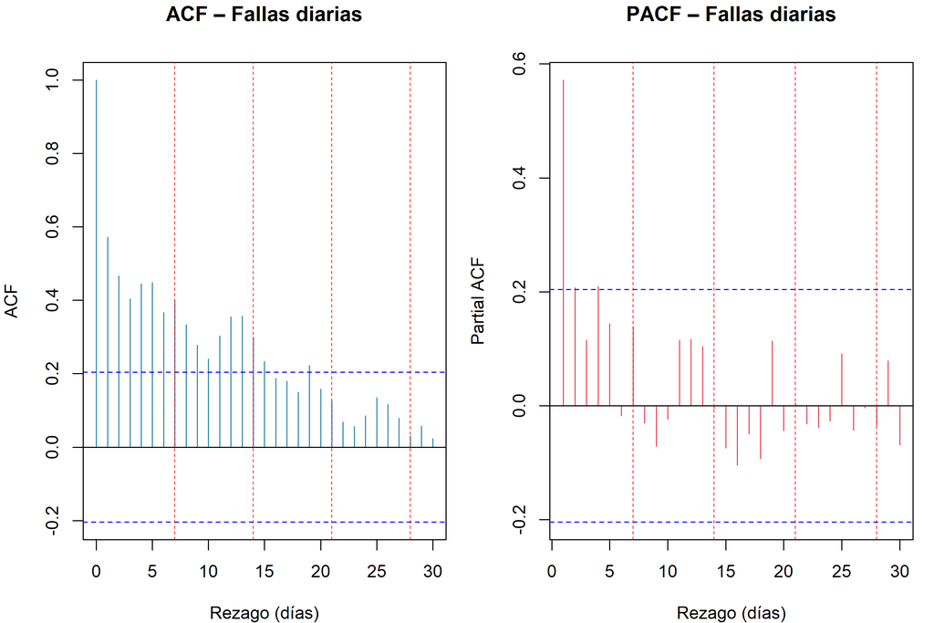

Figura 10. ACF y PACF de la serie diaria de fallas.

```r
fallas_ts <- fallas_diarias %>%
  arrange(FECHA_DIA) %>%
  pull(n_fallas)

par(mfrow = c(1, 2), mar = c(4, 4, 3, 1))
acf(fallas_ts,
    lag.max = 30,
    main    = "ACF – Fallas diarias",
    xlab    = "Rezago (días)",
    col     = "#2E86AB")
abline(v = 7 * (1:4), col = "red", lty = 2, lwd = 0.8)

pacf(fallas_ts,
     lag.max = 30,
     main    = "PACF – Fallas diarias",
     xlab    = "Rezago (días)",
     col     = "#E84855")
abline(v = 7 * (1:4), col = "red", lty = 2, lwd = 0.8)
```

```r
par(mfrow = c(1, 1))
```

```r
# Verificar autocorrelación en rezago 7
acf_vals <- acf(fallas_ts, lag.max = 30, plot = FALSE)
rho_7 <- acf_vals$acf[8]  # índice 8 = rezago 7

cat("Autocorrelación en rezago 7 días:", round(rho_7, 4), "\n")
```

```
## Autocorrelación en rezago 7 días: 0.4003
```

```r
cat("IC 95% bajo H0 (ruido blanco):", round(qnorm(0.975) / sqrt(length(fallas_ts)), 4), "\n")
```

```
## IC 95% bajo H0 (ruido blanco): 0.2043
```

```r
cat(ifelse(abs(rho_7) > qnorm(0.975) / sqrt(length(fallas_ts)),
           "→ Ciclo semanal estadísticamente significativo.",
           "→ No hay ciclo semanal claro."), "\n")
```

```
## → Ciclo semanal estadísticamente significativo.
```

## 7.2 Comparación de variabilidad: día vs. semana

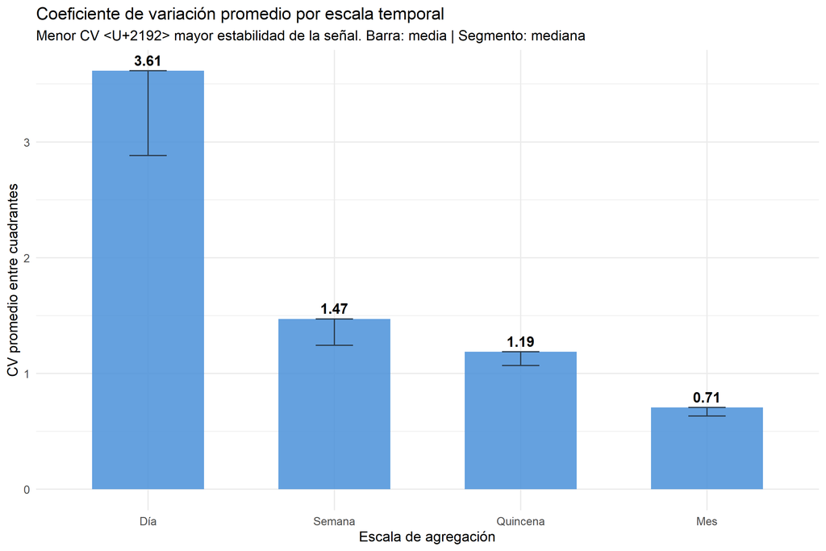

Figura 11. Coeficiente de variación a distintas escalas temporales de agregación.

```r
cv_escala <- datos_q4 %>%
  filter(!is.na(id_cuadrante)) %>%
  mutate(
    semana   = floor_date(FECHA_DIA, "week", week_start = 1),
    # lubridate no admite floor_date(..., "2 weeks"); bins de 14 días desde 2021-01-01
    quincena = as.Date("2021-01-01") + 14L * ((as.integer(FECHA_DIA - as.Date("2021-01-01"))) %/% 14L),
    mes      = floor_date(FECHA_DIA, "month")
  ) %>%
  pivot_longer(cols = c(FECHA_DIA, semana, quincena, mes),
               names_to = "escala", values_to = "periodo") %>%
  group_by(escala, id_cuadrante, periodo) %>%
  summarise(n_ev = sum(FRECUENCIA, na.rm = TRUE), .groups = "drop") %>%
  group_by(escala, id_cuadrante) %>%
  summarise(cv = sd(n_ev, na.rm = TRUE) / (mean(n_ev, na.rm = TRUE) + 1e-9),
            .groups = "drop") %>%
  group_by(escala) %>%
  summarise(cv_medio = mean(cv), cv_mediana = median(cv), .groups = "drop") %>%
  mutate(escala = factor(escala,
                         levels = c("FECHA_DIA", "semana", "quincena", "mes"),
                         labels = c("Día", "Semana", "Quincena", "Mes")))

ggplot(cv_escala, aes(x = escala, y = cv_medio)) +
  geom_col(fill = "#4A90D9", alpha = 0.85, width = 0.6) +
  geom_errorbar(aes(ymin = cv_mediana, ymax = cv_medio), width = 0.2, color = "#2C3E50") +
  geom_text(aes(label = round(cv_medio, 2)), vjust = -0.5, size = 4, fontface = "bold") +
  labs(
    title    = "Coeficiente de variación promedio por escala temporal",
    subtitle = "Menor CV → mayor estabilidad de la señal. Barra: media | Segmento: mediana",
    x = "Escala de agregación", y = "CV promedio entre cuadrantes"
  ) +
  theme_minimal(base_size = 11)
```

# 8 Validación del tamaño de los cuadrantes

## 8.1 Comparación entre alcance geoestadístico y tamaño del cuadrante

```r
# Estimar tamaño típico de un cuadrante
cuad_tamanio <- cuad_con_datos %>%
  arrange(lon, lat) %>%
  mutate(
    dist_lon = abs(lon - lag(lon, default = first(lon))),
    dist_lat = abs(lat - lag(lat, default = first(lat)))
  ) %>%
  summarise(
    lon_min = min(lon), lon_max = max(lon),
    lat_min = min(lat), lat_max = max(lat),
    n_cuad  = n()
  )

# Estimación del tamaño de cuadrante asumiendo grilla regular
area_total_lon <- cuad_tamanio$lon_max - cuad_tamanio$lon_min
area_total_lat <- cuad_tamanio$lat_max - cuad_tamanio$lat_min

# Grilla aproximada: sqrt(n) × sqrt(n)
n_cuad <- cuad_tamanio$n_cuad
lado_lon_grados <- area_total_lon / sqrt(n_cuad)
lado_lat_grados <- area_total_lat / sqrt(n_cuad)
lado_km         <- mean(c(lado_lon_grados, lado_lat_grados)) * 111

comparacion <- tibble(
  Métrica = c(
    "Alcance geoestadístico (range del semivariograma)",
    "Radio de máximo agrupamiento (función K)",
    "Tamaño estimado del lado del cuadrante",
    "N° cuadrantes con datos"
  ),
  `Valor (km)` = c(
    round(range_val * 111, 2),
    round(r_max_cluster * 111, 2),
    round(lado_km, 2),
    n_cuad
  ),
  Fuente = c(
    "Semivariograma esférico ajustado",
    "Función L(r)–r de Ripley",
    "Extensión geográfica / √N cuadrantes",
    "ELEMENTO_FALLA_CUADRANTE_800.xls"
  )
)

kable(comparacion,
      caption = "Tabla 4. Comparación entre escala de dependencia espacial y tamaño del cuadrante") %>%
  kable_styling(bootstrap_options = c("striped", "hover"), full_width = FALSE) %>%
  column_spec(1, bold = TRUE)
```

Tabla 4. Comparación entre escala de dependencia espacial y tamaño del cuadrante

| Métrica | Valor (km) | Fuente |
| --- | --- | --- |
| Alcance geoestadístico (range del semivariograma) | 55.50 | Semivariograma esférico ajustado |
| Radio de máximo agrupamiento (función K) | 52.02 | Función L(r)–r de Ripley |
| Tamaño estimado del lado del cuadrante | 12.43 | Extensión geográfica / vN cuadrantes |
| N° cuadrantes con datos | 290.00 | ELEMENTO_FALLA_CUADRANTE_800.xls |